# Exploratory Data Analysis

### Marc Anthony B Reyes

Growth Data Analyst Applicant | hello@marcreyes.ph | (+63)9129152323

## Initial Exploration of Dataset

On this part we will explore into the dataset as to what it contains, spefically the column names, and the summary of the aggregate values on each column.

- **Audio analysis features**: tempo, duration, mode, loudness, key, time signature, section start
- **Artist related features**: artist familiarlity, artist popularity, artist name, artist location
- **Song related features**: releases, title, year, song hotness

Many fields in the dataset were unusable due to old deprecated data. Many data fields were missing and there was no echonest API to fill in data since the API was modified by Spotify. Therefore many fields had to be dropped.

```python
# Data imports
import numpy as np
import pandas as pd
import matplotlib.pyplot as plt
import seaborn as sb
import time
import glob
import datetime
import sqlite3
import warnings
from matplotlib import rcParams

plt.style.use('fivethirtyeight')
rcParams['font.size'] = 15
rcParams["figure.figsize"] = [20,10]
warnings.filterwarnings("ignore")
```

```python
# Import the master one (1) million song dataset file into a dataframe
track_data = pd.read_csv('data/song_data.csv', index_col=0)
```

```python
# See a summary of the columns of each dataset such as standard deviation, mean, etc
track_data.describe()
```

|  | analysis_sample_rate | danceability | duration | end_of_fade_in | energy | bars_confidence | bars_start | beats_confidence | beats_start | sections_confidence | ... | artist_longitude | artist_playmeid | genre | artist_terms | similar_artists | release_7digitalid | song_hotttnesss | track_7digitalid | artist_mbtags | year |
| --- | --- | --- | --- | --- | --- | --- | --- | --- | --- | --- | --- | --- | --- | --- | --- | --- | --- | --- | --- | --- | --- |
| count | 1000000.0 | 1000000.0 | 1000000.000000 | 1000000.000000 | 1000000.0 | 1000000.0 | 1000000.0 | 1000000.0 | 1000000.0 | 1000000.0 | ... | 357492.000000 | 1000000.000000 | 0.0 | 1000000.0 | 1000000.0 | 1000000.000000 | 581965.000000 | 1.000000e+06 | 1000000.0 | 1000000.000000 |
| mean | 22050.0 | 0.0 | 249.500755 | 0.819850 | 0.0 | 0.0 | 0.0 | 0.0 | 0.0 | 0.0 | ... | -58.370804 | 26302.206937 | NaN | 0.0 | 0.0 | 379884.834575 | 0.356051 | 4.213995e+06 | 0.0 | 1030.325652 |
| std | 0.0 | 0.0 | 126.229636 | 3.304457 | 0.0 | 0.0 | 0.0 | 0.0 | 0.0 | 0.0 | ... | 54.955555 | 47052.147503 | NaN | 0.0 | 0.0 | 237443.651689 | 0.234441 | 2.640600e+06 | 0.0 | 998.745002 |
| min | 22050.0 | 0.0 | 0.313020 | 0.000000 | 0.0 | 0.0 | 0.0 | 0.0 | 0.0 | 0.0 | ... | -162.436500 | -1.000000 | NaN | 0.0 | 0.0 | -1.000000 | 0.000000 | -1.000000e+00 | 0.0 | 0.000000 |
| 25% | 22050.0 | 0.0 | 180.740770 | 0.000000 | 0.0 | 0.0 | 0.0 | 0.0 | 0.0 | 0.0 | ... | -91.523820 | -1.000000 | NaN | 0.0 | 0.0 | 179685.000000 | 0.215080 | 1.974300e+06 | 0.0 | 0.000000 |
| 50% | 22050.0 | 0.0 | 228.858320 | 0.194000 | 0.0 | 0.0 | 0.0 | 0.0 | 0.0 | 0.0 | ... | -77.366920 | 48.000000 | NaN | 0.0 | 0.0 | 350853.000000 | 0.377532 | 3.947503e+06 | 0.0 | 1969.000000 |
| 75% | 22050.0 | 0.0 | 289.932610 | 0.432000 | 0.0 | 0.0 | 0.0 | 0.0 | 0.0 | 0.0 | ... | -2.232180 | 33964.000000 | NaN | 0.0 | 0.0 | 582854.750000 | 0.531985 | 6.469678e+06 | 0.0 | 2002.000000 |
| max | 22050.0 | 0.0 | 3034.905670 | 1163.941000 | 0.0 | 0.0 | 0.0 | 0.0 | 0.0 | 0.0 | ... | 178.690960 | 242965.000000 | NaN | 0.0 | 0.0 | 823654.000000 | 1.000000 | 9.091277e+06 | 0.0 | 2011.000000 |

8 rows × 44 columns

### Histogram: Learn about the distribution of the variables

On this part, we will look into the distribution of the some variables that are in the dataset.

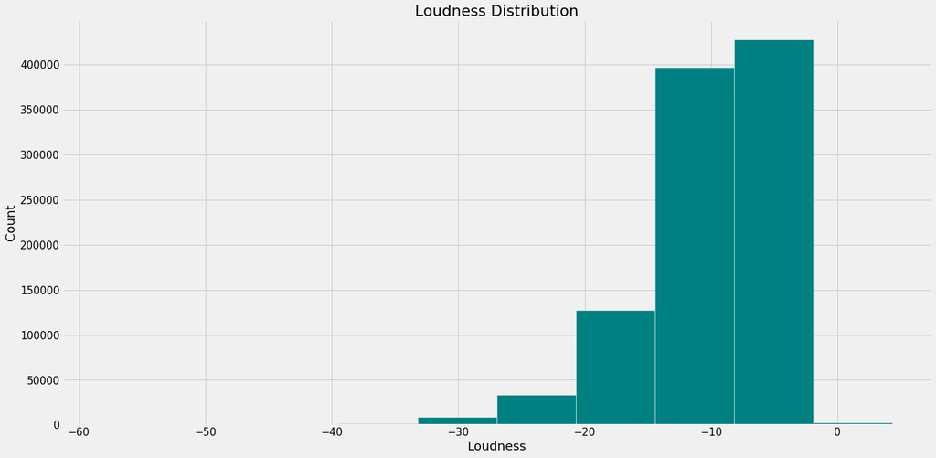

```python
# Plot the loudness distribution on the dataset
plt.hist(track_data.loudness, color='#008080', edgecolor='white')
plt.xlabel("Loudness")
plt.ylabel("Count")
plt.title("Loudness Distribution")
```

### Scatterplots: Relationships between variables

On this part, we will look into the relationship of two interrelated variables such as `artist_familiartity` and `artist_hotttnesss`, `artist_hotttnesss` and `song_hotttnesss`, and `artist_familiarity` and `song_hotttnesss`.

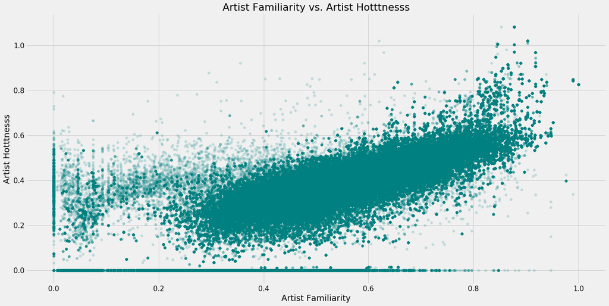

```python
# Scatter plot artist_familiarity vis-a-vis artist_hotttnesss
plt.scatter(track_data.artist_familiarity, track_data.artist_hotttnesss, lw=0, alpha=.2, color='#008080')
plt.xlabel("Artist Familiarity")
plt.ylabel("Artist Hotttnesss")
plt.title("Artist Familiarity vs. Artist Hotttnesss")
```

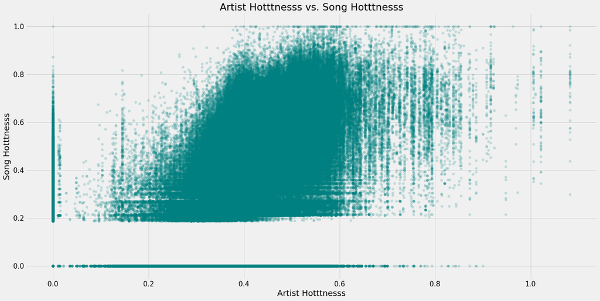

```python
# Scatter plot artist_hotttnesss and song_hotttnesss
plt.scatter(track_data.artist_hotttnesss, track_data.song_hotttnesss, lw=0, alpha=.2, color='#008080')
plt.xlabel("Artist Hotttnesss")
plt.ylabel("Song Hotttnesss")
plt.title("Artist Hotttnesss vs. Song Hotttnesss")
```

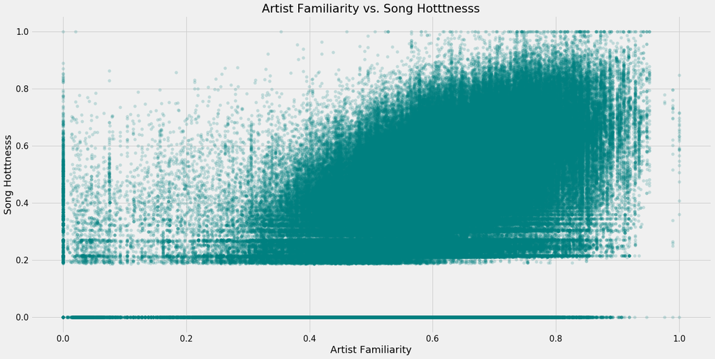

```python
# Scatter plot artist_familiarity and song_hotttnesss
plt.scatter(track_data.artist_familiarity, track_data.song_hotttnesss, lw=0, alpha=.2, color='#008080')
plt.xlabel("Artist Familiarity")
plt.ylabel("Song Hotttnesss")
plt.title("Artist Familiarity vs. Song Hotttnesss")
```

### Add Genre data

In the original data of the million song dataset, the genre is not provided. However, a pre-made genre data assigned to track_id has been provided by one researcher who has worked with the idenitification of each genre. The genre-track_id data could be found here: http://www.ifs.tuwien.ac.at/mir/msd/partitions/msd-MAGD-genreAssignment.cls.

```python
# Import the track_id, genre_id file into a dataframe
genre = pd.read_csv('data/genre_data.cls', sep='\t')
```

```python
# Name columns for the genre dataframe
genre.columns=['track_id','genre_id']
```

```python
# See the first five rows of the dataframe
genre.head()
```

|  | track_id | genre_id |
| --- | --- | --- |
| 0 | TRAAAAV128F421A322 | Pop_Rock |
| 1 | TRAAAAW128F429D538 | Rap |
| 2 | TRAAABD128F429CF47 | Pop_Rock |
| 3 | TRAAACV128F423E09E | Pop_Rock |
| 4 | TRAAADT12903CCC339 | Easy_Listening |

```python
# Show an array of the unique genre in the genre_id dataframe column
genre.genre_id.unique()
```

```
array(['Pop_Rock', 'Rap', 'Easy_Listening', 'Vocal', 'Electronic',
       'Blues', 'RnB', 'Folk', 'Religious', 'Country', 'Jazz', 'New Age',
       'Latin', 'International', 'Comedy_Spoken', 'Reggae', 'Stage ',
       'Children', 'Classical', 'Avant_Garde', 'Holiday'], dtype=object)
```

```python
# We merge the original song data to the genre data.
# The key is track_id and this will create a new dataframe
# that contains rows has track_id of both track_data dataframe (original)
# and genre dataframe (with track_id, genre_id)
data_with_genre = pd.merge(track_data, genre, on='track_id')
```

```python
# See the first five rows of the dataframe
data_with_genre.head()
```

|  | analysis_sample_rate | audio_md5 | danceability | duration | end_of_fade_in | energy | bars_confidence | bars_start | beats_confidence | beats_start | ... | similar_artists | release | release_7digitalid | song_hotttnesss | song_id | title | track_7digitalid | artist_mbtags | year | genre_id |
| --- | --- | --- | --- | --- | --- | --- | --- | --- | --- | --- | --- | --- | --- | --- | --- | --- | --- | --- | --- | --- | --- |
| 0 | 22050 | 96c7104889a128fef84fa469d60e380c | 0.0 | 138.97098 | 0.000 | 0.0 | 0 | 0 | 0 | 0 | ... | 0 | Butter | 625706 | 0.617871 | SOGTUKN12AB017F4F1 | No One Could Ever | 6945353 | 0 | 2006 | Electronic |
| 1 | 22050 | 0f7da84b6b583e3846c7e022fb3a92a2 | 0.0 | 145.05751 | 0.000 | 0.0 | 0 | 0 | 0 | 0 | ... | 0 | De Culo | 199368 | NaN | SOBNYVR12A8C13558C | Si Vos Querés | 2168257 | 0 | 2003 | International |
| 2 | 22050 | c5eaa27a919d3403cb12745056de0b21 | 0.0 | 221.20444 | 0.165 | 0.0 | 0 | 0 | 0 | 0 | ... | 0 | Da Bomb | 580432 | NaN | SOEYRFT12AB018936C | 2 Da Beat Ch'yall | 6435649 | 0 | 1993 | Rap |
| 3 | 22050 | 3510d0c3bac6ed15aaab6876be4317a3 | 0.0 | 301.60934 | 0.000 | 0.0 | 0 | 0 | 0 | 0 | ... | 0 | International Hardcore Superstar | 620618 | 0.392009 | SOQQESG12A58A7AA28 | Cold Beer feat. Prince Metropolitan | 6893903 | 0 | 0 | Pop_Rock |
| 4 | 22050 | 873d1d86b520c89ae05492b8f577afdd | 0.0 | 318.45832 | 0.502 | 0.0 | 0 | 0 | 0 | 0 | ... | 0 | The Loyal | 204414 | 0.463490 | SOMPVQB12A8C1379BB | Pilots | 2218694 | 0 | 2005 | Pop_Rock |

5 rows × 54 columns

### Adding Country data

In the original million song dataset, the country is not provided. However, the `artist_latitude` and `artist_longitude` columns are provided for us. We could use this to do a reverse geocoding using **reverse_geocode**, a python library for reverse geocoding latitude and longitude data.

```python
# Library imports
import math, reverse_geocode

# Get the latitude and longitude columns and store in a variable
artist_latitude = data_with_genre['artist_latitude']
artist_longitude = data_with_genre['artist_longitude']

# Create a blank list. We will append reverse geocoded countries
# on this list
countries = []
```

```python
# On this part, we will do a reverse geocoding of all rows with latitude
# and longitude data. We then store the reverse geocoded value in
# a list and append it into the main dataframe later.
for i in range(len(artist_latitude)):
    # Get the latitude dataframe cell and store in a variable
    latitude = artist_latitude.iloc[i]
    # Get the longitude dataframe cell and store in a variable
    longitude = artist_longitude.iloc[i]

    # There are artist_longitude and artist_latitude that are
    # null so if we detect at least one null of both values
    # then we skip them and instead, append a blank
    # value in the list.
    if (math.isnan(latitude) or math.isnan(longitude)):
        countries.append('')
    # If both artist_longitude and artist_latitude values
    # are present, we do a reverse geocoding and append
    # these values into a dataframe
    else:
        coordinates = (latitude, longitude),
        # Do a reverse geocoding
        country_data = reverse_geocode.search(coordinates)
        # Append to list
        countries.append(country_data[0]['country'])
```

```python
# We convert the list to a dataframe
country_df = pd.DataFrame(countries)
```

```python
# Give the dataframe a column name
country_df.columns = ['country']
```

```python
# See the first five rows of the dataframe
country_df.head()
```

|  | country |
| --- | --- |
| 0 | United Kingdom |
| 1 |  |
| 2 |  |
| 3 |  |
| 4 |  |

```python
# We then combine the country_dataframe to the main dataframe
data_with_genre = data_with_genre.join(country_df)
```

```python
# See the first five rows of the dataframe
data_with_genre.head()
```

|  | analysis_sample_rate | audio_md5 | danceability | duration | end_of_fade_in | energy | bars_confidence | bars_start | beats_confidence | beats_start | ... | release | release_7digitalid | song_hotttnesss | song_id | title | track_7digitalid | artist_mbtags | year | genre_id | country |
| --- | --- | --- | --- | --- | --- | --- | --- | --- | --- | --- | --- | --- | --- | --- | --- | --- | --- | --- | --- | --- | --- |
| 0 | 22050 | 96c7104889a128fef84fa469d60e380c | 0.0 | 138.97098 | 0.000 | 0.0 | 0 | 0 | 0 | 0 | ... | Butter | 625706 | 0.617871 | SOGTUKN12AB017F4F1 | No One Could Ever | 6945353 | 0 | 2006 | Electronic | United Kingdom |
| 1 | 22050 | 0f7da84b6b583e3846c7e022fb3a92a2 | 0.0 | 145.05751 | 0.000 | 0.0 | 0 | 0 | 0 | 0 | ... | De Culo | 199368 | NaN | SOBNYVR12A8C13558C | Si Vos Querés | 2168257 | 0 | 2003 | International |  |
| 2 | 22050 | c5eaa27a919d3403cb12745056de0b21 | 0.0 | 221.20444 | 0.165 | 0.0 | 0 | 0 | 0 | 0 | ... | Da Bomb | 580432 | NaN | SOEYRFT12AB018936C | 2 Da Beat Ch'yall | 6435649 | 0 | 1993 | Rap |  |
| 3 | 22050 | 3510d0c3bac6ed15aaab6876be4317a3 | 0.0 | 301.60934 | 0.000 | 0.0 | 0 | 0 | 0 | 0 | ... | International Hardcore Superstar | 620618 | 0.392009 | SOQQESG12A58A7AA28 | Cold Beer feat. Prince Metropolitan | 6893903 | 0 | 0 | Pop_Rock |  |
| 4 | 22050 | 873d1d86b520c89ae05492b8f577afdd | 0.0 | 318.45832 | 0.502 | 0.0 | 0 | 0 | 0 | 0 | ... | The Loyal | 204414 | 0.463490 | SOMPVQB12A8C1379BB | Pilots | 2218694 | 0 | 2005 | Pop_Rock |  |

5 rows × 55 columns

```python
# Store this into a csv file on which we will use later
data_with_genre.to_csv('data/song_data_with_genre_and_country.csv', index=False)
```

### Song Hotttnesss over the years by specific genres

On this part, we will do a data visualization of the `song_hotttnesss` data over the years on specific genres that are presently heard commonly, namely `Pop_Rock`, `Latin`, `Rap`, `Electronic`, `Country`, and `RnB`.

```python
# Create a new subset dataframe from data_with_genre dataframe with specifif genres
data_with_genre_2 = data_with_genre[data_with_genre.genre_id.isin(['Pop_Rock', 'Latin', 'Rap', 'Electronic', 'Country', 'RnB'])]
# Convert to data to dataframe
data_with_genre_2 = pd.DataFrame(data_with_genre)
# Only select rows with non-zero values in artist_hotttnesss and artist_familiarity
data_with_genre_2 = data_with_genre_2[(data_with_genre_2.artist_hotttnesss != 0) & (data_with_genre_2.artist_familiarity != 0) & (data_with_genre_2.song_hotttnesss != 0) & (data_with_genre_2.year != 0)]
```

#### Scatter plot of `Pop_Rock`, `Latin`, `Rap`, `Electronic`, `Country`

On this part, we will show `song_hotttnesss` data of the genres mentioned throughout the years.

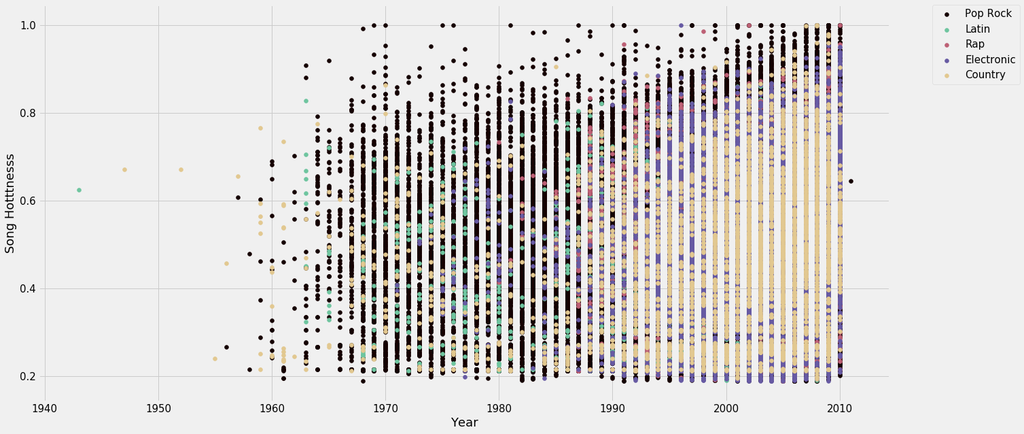

```python
# Pop_Rock
plt.scatter(data_with_genre_2['year'][data_with_genre_2['genre_id'] == 'Pop_Rock'],
            data_with_genre_2['song_hotttnesss'][data_with_genre_2['genre_id'] == 'Pop_Rock'],
            # the color
            color='#150101',
            # labelled this
            label='Pop Rock')

# Latin
plt.scatter(data_with_genre_2['year'][data_with_genre_2['genre_id'] == 'Latin'],
            data_with_genre_2['song_hotttnesss'][data_with_genre_2['genre_id'] == 'Latin'],
            # the color
            color='#6ec59f',
            # alpha
            # labelled this
            label='Latin')

# Rap
plt.scatter(data_with_genre_2['year'][data_with_genre_2['genre_id'] == 'Rap'],
            data_with_genre_2['song_hotttnesss'][data_with_genre_2['genre_id'] == 'Rap'],
            # the color
            color='#bd6075',
            # labelled this
            label='Rap')

# Electronic
plt.scatter(data_with_genre_2['year'][data_with_genre_2['genre_id'] == 'Electronic'],
            data_with_genre_2['song_hotttnesss'][data_with_genre_2['genre_id'] == 'Electronic'],
            # the color
            color='#675aa3',
            # labelled this
            label='Electronic')

            # Country
plt.scatter(data_with_genre_2['year'][data_with_genre_2['genre_id'] == 'Country'],
            data_with_genre_2['song_hotttnesss'][data_with_genre_2['genre_id'] == 'Country'],
            # the color
            color='#e2c890',
            # labelled this
            label='Country')


plt.legend(bbox_to_anchor=(1.05, 1), loc=2, borderaxespad=0.)
plt.xlabel('Year')
plt.ylabel('Song Hotttnesss')
```

```python
# Show songs with song_hotttnesss of one (1)
data_with_genre_2[data_with_genre_2.song_hotttnesss == 1]
```

|  | analysis_sample_rate | audio_md5 | danceability | duration | end_of_fade_in | energy | bars_confidence | bars_start | beats_confidence | beats_start | ... | release | release_7digitalid | song_hotttnesss | song_id | title | track_7digitalid | artist_mbtags | year | genre_id | country |
| --- | --- | --- | --- | --- | --- | --- | --- | --- | --- | --- | --- | --- | --- | --- | --- | --- | --- | --- | --- | --- | --- |
| 936 | 22050 | e0a6385f0cf30208d36fd79db25c72cf | 0.0 | 235.15383 | 4.348 | 0.0 | 0 | 0 | 0 | 0 | ... | Hot Fuss | 401785 | 1.0 | SOFHTIO12A6D4F6128 | Smile Like You Mean It | 4465245 | 0 | 2003 | Pop_Rock |  |
| 16829 | 22050 | e4d1e6d9a725e130e572391ec98b346d | 0.0 | 218.56608 | 1.001 | 0.0 | 0 | 0 | 0 | 0 | ... | Reptilia | 268146 | 1.0 | SOHJUEQ12A8C143421 | Reptilia | 2948903 | 0 | 2003 | Pop_Rock | United States |
| 35130 | 22050 | 828b96e5a66d356fd0dba021fbddee66 | 0.0 | 202.73587 | 0.060 | 0.0 | 0 | 0 | 0 | 0 | ... | Party In The U.S.A. | 580462 | 1.0 | SOVWADY12AB0189C63 | Party In The U.S.A. | 6433137 | 0 | 2009 | Pop_Rock |  |
| 36356 | 22050 | a4f8be82dbcd9a799df949eadc1c18a0 | 0.0 | 214.75220 | 0.171 | 0.0 | 0 | 0 | 0 | 0 | ... | Cooler Than Me | 783618 | 1.0 | SOBQYCF12AC909726F | Cooler Than Me | 8666941 | 0 | 2010 | Pop_Rock |  |
| 59505 | 22050 | 0cda045c30d07263a04cdc3c316d05ec | 0.0 | 175.12444 | 0.000 | 0.0 | 0 | 0 | 0 | 0 | ... | Cage The Elephant | 267814 | 1.0 | SOJTLHS12A8C13F633 | Ain't No Rest For The Wicked (Original Version) | 2946131 | 0 | 2008 | Pop_Rock |  |
| 68831 | 22050 | f5f36e3562b8efd8ff7b89e9aa3dfd25 | 0.0 | 238.70649 | 0.212 | 0.0 | 0 | 0 | 0 | 0 | ... | All The Right Moves | 618210 | 1.0 | SOWREII12AAF3B43F1 | All The Right Moves | 6866567 | 0 | 2009 | Pop_Rock |  |
| 82753 | 22050 | d16978369909781dcafcc2e58edc4bf7 | 0.0 | 219.81995 | 5.393 | 0.0 | 0 | 0 | 0 | 0 | ... | Room On Fire | 527362 | 1.0 | SOHJUEQ12A8C143421 | Reptilia | 5828056 | 0 | 2003 | Pop_Rock | United States |
| 84037 | 22050 | a8dfa3929df172aff38b06b1fd329203 | 0.0 | 166.00771 | 0.130 | 0.0 | 0 | 0 | 0 | 0 | ... | Bleed American | 15460 | 1.0 | SORWLTW12A670208FA | The Middle | 161986 | 0 | 2001 | Pop_Rock | United States |
| 102071 | 22050 | 4c9eeea07ea3177de74bc67260350ceb | 0.0 | 145.05751 | 2.223 | 0.0 | 0 | 0 | 0 | 0 | ... | Led Zeppelin III | 171807 | 1.0 | SOAAXAK12A8C13C030 | Immigrant Song (Album Version) | 2315490 | 0 | 1970 | Pop_Rock |  |
| 111762 | 22050 | 05a1670f3c9899b4c97b204286a2b1ad | 0.0 | 262.42567 | 0.000 | 0.0 | 0 | 0 | 0 | 0 | ... | War Is The Answer | 577899 | 1.0 | SOYGHUM12AB018139C | Bad Company | 6394998 | 0 | 2009 | Pop_Rock |  |
| 121427 | 22050 | a5fd84d1b29c8c377f7a5f79fd0755d2 | 0.0 | 281.54730 | 0.154 | 0.0 | 0 | 0 | 0 | 0 | ... | All I Ever Wanted | 393179 | 1.0 | SOFGJCW12AF72A812D | Already Gone | 4386642 | 0 | 2009 | Pop_Rock |  |
| 128277 | 22050 | 3bf0d21a8096198ab4f5822d80232d5d | 0.0 | 245.52444 | 0.131 | 0.0 | 0 | 0 | 0 | 0 | ... | Fantasies | 407587 | 1.0 | SOUOPLF12AB017F40F | Gold Guns Girls | 4532150 | 0 | 2009 | Pop_Rock |  |
| 130607 | 22050 | eaca6297ae149eefff2b94ab2a21f61b | 0.0 | 203.98975 | 0.157 | 0.0 | 0 | 0 | 0 | 0 | ... | Let Go | 403018 | 1.0 | SOZEXFT12AF72A2578 | Sk8er Boi | 4480974 | 0 | 2002 | Pop_Rock | Canada |
| 135125 | 22050 | 532daf5f475ee8f32c52059cc70f410d | 0.0 | 311.27465 | 0.365 | 0.0 | 0 | 0 | 0 | 0 | ... | The Scientist | 310 | 1.0 | SOKLRPJ12A8C13C3FE | The Scientist | 3009 | 0 | 2002 | Pop_Rock |  |
| 140576 | 22050 | 241b5e6c35b02a4131bac160e8852ebb | 0.0 | 138.29179 | 0.000 | 0.0 | 0 | 0 | 0 | 0 | ... | Contra | 667809 | 1.0 | SOEWAKD12AB01860D5 | Holiday | 7404103 | 0 | 2010 | Pop_Rock | United States |
| 141771 | 22050 | ca0188f45dee15bd1c3107b01759e045 | 0.0 | 211.56526 | 0.351 | 0.0 | 0 | 0 | 0 | 0 | ... | Little Sister | 362575 | 1.0 | SOLJEZT12A6702037C | Little Sister | 86248 | 0 | 2005 | Pop_Rock |  |
| 142642 | 22050 | 63c8dd40b80c2024feb284054018ee88 | 0.0 | 333.66159 | 3.471 | 0.0 | 0 | 0 | 0 | 0 | ... | Metallica | 38972 | 1.0 | SOCHYVZ12A6D4F5908 | Enter Sandman | 417163 | 0 | 1991 | Pop_Rock |  |
| 143558 | 22050 | 9356ffd8865e5201ffed807d8c4a379d | 0.0 | 175.07220 | 0.000 | 0.0 | 0 | 0 | 0 | 0 | ... | Chunk of Change | 352369 | 1.0 | SOOIDEV12AB0184D02 | Sleepyhead | 3938491 | 0 | 2008 | Pop_Rock |  |
| 147354 | 22050 | 1196b019d3e1f1b4233116b58060c835 | 0.0 | 418.27220 | 0.136 | 0.0 | 0 | 0 | 0 | 0 | ... | Back To Black | 351772 | 1.0 | SOBUDTC12A6D4F854A | Rehab | 3931972 | 0 | 2006 | RnB |  |
| 155879 | 22050 | 130cd32840bb4b59596c56e9186b22ff | 0.0 | 225.61914 | 0.142 | 0.0 | 0 | 0 | 0 | 0 | ... | PCD | 21557 | 1.0 | SORLZXM12A67ADAEF5 | Buttons | 223559 | 0 | 2005 | Pop_Rock |  |
| 166152 | 22050 | 67ac565f2186f3b239146048ff68bdb7 | 0.0 | 164.17914 | 0.000 | 0.0 | 0 | 0 | 0 | 0 | ... | Something Good Can Work | 817697 | 1.0 | SOMIHYA12AB018DD37 | Something Good Can Work | 9033532 | 0 | 2009 | Pop_Rock |  |
| 168418 | 22050 | 7c2a326df35cf7a171756dffe6375e05 | 0.0 | 248.03220 | 4.203 | 0.0 | 0 | 0 | 0 | 0 | ... | A Beautiful Lie | 16369 | 1.0 | SOKEBLL12A58A8087C | From Yesterday | 174314 | 0 | 2005 | Pop_Rock |  |
| 168765 | 22050 | b33274cc4b768ea33b99a535723c88b1 | 0.0 | 259.94404 | 0.000 | 0.0 | 0 | 0 | 0 | 0 | ... | Women In Technology | 154648 | 1.0 | SOCRCNK12A8C133AA7 | Your Woman | 1616531 | 0 | 1996 | Electronic | United Kingdom |
| 173711 | 22050 | 981b09cb93d1565a82c4eb41a73ac8ed | 0.0 | 231.81016 | 4.017 | 0.0 | 0 | 0 | 0 | 0 | ... | Use Somebody | 341653 | 1.0 | SOWCKVR12A8C142411 | Use Somebody | 3824884 | 0 | 2008 | Pop_Rock | United States |
| 174574 | 22050 | 6ee8c8b7154a1f856df1fd4a8c76d81d | 0.0 | 281.83465 | 3.495 | 0.0 | 0 | 0 | 0 | 0 | ... | Wreck of the Day | 291847 | 1.0 | SORXSRO12A8C135C76 | Breathe (2 AM) | 3276723 | 0 | 2005 | Pop_Rock | United States |
| 177342 | 22050 | f50c00e0ac00fcc93e82839d38e98dd5 | 0.0 | 296.56771 | 0.000 | 0.0 | 0 | 0 | 0 | 0 | ... | Word Of Mouf | 8472 | 1.0 | SOJLWGO12A670201D0 | Rollout (My Business) | 85387 | 0 | 2002 | Rap |  |
| 179604 | 22050 | 759e2d7370b552192242b82516908c6e | 0.0 | 269.63546 | 5.283 | 0.0 | 0 | 0 | 0 | 0 | ... | B.o.B Presents: The Adventures of Bobby Ray | 803358 | 1.0 | SOULTKQ12AB018A183 | Nothin' On You [feat. Bruno Mars] (Album Version) | 8880639 | 0 | 2010 | Rap | United States |
| 186281 | 22050 | 92dce7d6520d9c734bc0e963c797407f | 0.0 | 360.25424 | 0.938 | 0.0 | 0 | 0 | 0 | 0 | ... | Bitter Sweet Symphony | 1078 | 1.0 | SOXQYSC12A6310E908 | Bitter Sweet Symphony | 9634 | 0 | 1997 | Pop_Rock |  |
| 189433 | 22050 | 5ce63ed9049e2f524784aa1e881ad8db | 0.0 | 240.03873 | 2.543 | 0.0 | 0 | 0 | 0 | 0 | ... | Life For Rent | 279034 | 1.0 | SOHGFPP12A8AE4624D | White Flag | 3107323 | 0 | 2003 | Pop_Rock |  |
| 207593 | 22050 | 90788f170d4608a769d6a9abd771703d | 0.0 | 326.97424 | 2.937 | 0.0 | 0 | 0 | 0 | 0 | ... | This Is War | 656036 | 1.0 | SOXXMPD12AB0185A52 | This Is War | 7266158 | 0 | 2009 | Pop_Rock |  |
| ... | ... | ... | ... | ... | ... | ... | ... | ... | ... | ... | ... | ... | ... | ... | ... | ... | ... | ... | ... | ... | ... |
| 301325 | 22050 | 7b3e77af76138b2f13c220a4919efce9 | 0.0 | 230.47791 | 0.357 | 0.0 | 0 | 0 | 0 | 0 | ... | Fearless | 407425 | 1.0 | SOSROFB12AAF3B4C5D | You Belong With Me | 4526501 | 0 | 2008 | Country |  |
| 311420 | 22050 | 8df9e97663cc4b7cc1e5f8436804ae88 | 0.0 | 197.53751 | 0.409 | 0.0 | 0 | 0 | 0 | 0 | ... | Is This It | 268143 | 1.0 | SOQFXDQ12AF72AD0EE | Last Nite | 2948863 | 0 | 2001 | Pop_Rock | United States |
| 313521 | 22050 | c0e2af40f5d3acdd609259b62b87ad10 | 0.0 | 232.61995 | 1.083 | 0.0 | 0 | 0 | 0 | 0 | ... | Seven Nation Army | 275265 | 1.0 | SOAUFOF12AB0180C65 | Seven Nation Army | 3059734 | 0 | 2003 | Pop_Rock | Canada |
| 315555 | 22050 | 524259753bf14dcd8d28918ddcacf11b | 0.0 | 215.56200 | 0.578 | 0.0 | 0 | 0 | 0 | 0 | ... | Alice | 754590 | 1.0 | SOTSJDX12AF72A9AFD | Alice | 8353324 | 0 | 2010 | Pop_Rock | Canada |
| 322056 | 22050 | 0d56594a64a4d0a93d1903c726761585 | 0.0 | 259.94404 | 0.000 | 0.0 | 0 | 0 | 0 | 0 | ... | Drops Of Jupiter | 288056 | 1.0 | SOVXBOT12A8C136816 | Drops Of Jupiter | 3232909 | 0 | 2001 | Pop_Rock | United States |
| 331883 | 22050 | e08197691971f4912a3dcdaebc6cd245 | 0.0 | 316.78649 | 5.939 | 0.0 | 0 | 0 | 0 | 0 | ... | Here With Me | 299112 | 1.0 | SORZBBD12A3F1EC477 | Here With Me | 3359327 | 0 | 1999 | Pop_Rock |  |
| 331898 | 22050 | af57a9da827ec1d394385d94a59714d0 | 0.0 | 206.36689 | 0.248 | 0.0 | 0 | 0 | 0 | 0 | ... | All Star Smash Hits | 18514 | 1.0 | SOBCOWD12A6701FD78 | Walkin' On The Sun | 196826 | 0 | 1997 | Pop_Rock |  |
| 332316 | 22050 | 8e05fa1d6c5fbd60edf7ce46c1fde54a | 0.0 | 319.86893 | 0.125 | 0.0 | 0 | 0 | 0 | 0 | ... | The Very Best Of Dan Fogelberg | 287076 | 1.0 | SONGICF12A8C136F79 | Same Old Lang Syne | 3221811 | 0 | 1981 | Pop_Rock |  |
| 334752 | 22050 | 4f42c79bf3a8a729ba0af635beaaf58d | 0.0 | 231.81016 | 1.152 | 0.0 | 0 | 0 | 0 | 0 | ... | Elephant | 617477 | 1.0 | SOAUFOF12AB0180C65 | Seven Nation Army (Album Version) | 6860354 | 0 | 2003 | Pop_Rock | Canada |
| 341348 | 22050 | 97ed4296b399e2e8092eadc41a930681 | 0.0 | 289.61914 | 0.142 | 0.0 | 0 | 0 | 0 | 0 | ... | Singles 1968-1971 | 522674 | 1.0 | SOLHHEI12A8C1410A1 | You Can't Always Get What You Want | 5772011 | 0 | 1969 | Pop_Rock | United Kingdom |
| 342163 | 22050 | 90596550e7cf99c52441e2e3351ba622 | 0.0 | 214.75220 | 0.142 | 0.0 | 0 | 0 | 0 | 0 | ... | Vampire Weekend | 192457 | 1.0 | SOOZFCC12A58A7D783 | Cape Cod Kwassa Kwassa (Album) | 2093103 | 0 | 2007 | Pop_Rock | United States |
| 350422 | 22050 | c73813fe4e6adbde1afe00432ee01fd5 | 0.0 | 211.01669 | 0.122 | 0.0 | 0 | 0 | 0 | 0 | ... | Tighten Up | 806075 | 1.0 | SOVDLZN12AB0185BEA | Tighten Up | 8909852 | 0 | 2010 | Pop_Rock | United States |
| 352156 | 22050 | 5988fcbd378a1e48fa4f87af47866b4f | 0.0 | 343.66649 | 0.000 | 0.0 | 0 | 0 | 0 | 0 | ... | Ten | 494009 | 1.0 | SOIBLKQ12AB0183E85 | Black | 5475544 | 0 | 1991 | Pop_Rock | United States |
| 358205 | 22050 | 3e6bbf01d783ee3af62d9f3696eff04b | 0.0 | 177.52771 | 0.967 | 0.0 | 0 | 0 | 0 | 0 | ... | Starry Eyed | 743498 | 1.0 | SOKSMZU12AB01867E9 | Starry Eyed | 8230649 | 0 | 2010 | Pop_Rock |  |
| 358643 | 22050 | c3ab26815ffa7e61a15c22efa917bfac | 0.0 | 190.82404 | 0.229 | 0.0 | 0 | 0 | 0 | 0 | ... | First Day Of My Life | 139082 | 1.0 | SORGVYS12A8AE48882 | First Day Of My Life (Single Version) | 1444070 | 0 | 2005 | Pop_Rock |  |
| 362042 | 22050 | 11673bdb1d71f8734ba357890057f16a | 0.0 | 207.64689 | 0.154 | 0.0 | 0 | 0 | 0 | 0 | ... | In Between Dreams | 221729 | 1.0 | SOVGLTY12AF72A39CD | Better Together | 2424071 | 0 | 2005 | Pop_Rock |  |
| 364962 | 22050 | c1228ac7d736f1263aa4a8aa14b3043b | 0.0 | 224.67873 | 0.000 | 0.0 | 0 | 0 | 0 | 0 | ... | Waking Up | 630873 | 1.0 | SONYKOW12AB01849C9 | Secrets | 7001801 | 0 | 2009 | Pop_Rock |  |
| 366394 | 22050 | c5effd56512d7eb4b310e32c9c1c1117 | 0.0 | 233.89995 | 0.131 | 0.0 | 0 | 0 | 0 | 0 | ... | Fearless | 388478 | 1.0 | SOTWSXL12A8C143349 | Love Story | 4309424 | 0 | 2008 | Country |  |
| 367437 | 22050 | d27808725ff0d6f06d6d39beb3927d76 | 0.0 | 285.15220 | 4.075 | 0.0 | 0 | 0 | 0 | 0 | ... | Blood Bank | 360287 | 1.0 | SOHKKLT12A58A7C1C2 | Blood Bank | 4014552 | 0 | 2009 | Pop_Rock |  |
| 370414 | 22050 | 168af1a77bf124563d6591261592d410 | 0.0 | 323.42159 | 2.769 | 0.0 | 0 | 0 | 0 | 0 | ... | The Best Of Kansas | 286558 | 1.0 | SOXHTPJ12A8C132EFD | Carry On Wayward Son | 3207906 | 0 | 1976 | Pop_Rock | United States |
| 374675 | 22050 | c98c70773883cab33f8b76204e288d7e | 0.0 | 291.60444 | 0.514 | 0.0 | 0 | 0 | 0 | 0 | ... | The Best of Bobby McFerrin | 29308 | 1.0 | SOZBAAH12A6D4F959F | Don't Worry Be Happy | 323214 | 0 | 1989 | Vocal | United States |
| 389329 | 22050 | b3f55f671a155f0b07d193085f6af6e7 | 0.0 | 258.58567 | 0.404 | 0.0 | 0 | 0 | 0 | 0 | ... | Only Revolutions | 635865 | 1.0 | SOVWHPM12AB017DABB | Many Of Horror | 7057757 | 0 | 2009 | Pop_Rock |  |
| 390500 | 22050 | 750034814e6c060da16362e7b6d2ac8a | 0.0 | 275.80036 | 2.334 | 0.0 | 0 | 0 | 0 | 0 | ... | Official Live: 101 Proof | 65621 | 1.0 | SOIVSBM12A6D4FB1AE | Cowboys From Hell [Live Version] | 684491 | 0 | 1997 | Pop_Rock |  |
| 394484 | 22050 | b1bccbca0da98839c5bb34da1d91c5fe | 0.0 | 237.97506 | 3.779 | 0.0 | 0 | 0 | 0 | 0 | ... | Waking Up | 687286 | 1.0 | SOLWZVR12AB01849C6 | All The Right Moves | 7629937 | 0 | 2009 | Pop_Rock |  |
| 396916 | 22050 | 0301da2a0d55bee61e117a3a678b58cd | 0.0 | 318.58893 | 0.206 | 0.0 | 0 | 0 | 0 | 0 | ... | Ten | 283339 | 1.0 | SOBHHHO12A58A78B94 | Jeremy | 3166975 | 0 | 1991 | Pop_Rock | United States |
| 404307 | 22050 | e9b1ab41e2298ad7ced8be504664c0a0 | 0.0 | 347.03628 | 0.287 | 0.0 | 0 | 0 | 0 | 0 | ... | Kings and Queens | 646431 | 1.0 | SONKHWV12AF72A4046 | Kings and Queens | 7161792 | 0 | 2009 | Pop_Rock |  |
| 409883 | 22050 | 3e4d944f85e2fa5b07a215703d81376e | 0.0 | 270.54975 | 0.131 | 0.0 | 0 | 0 | 0 | 0 | ... | The Essential Bruce Springsteen | 547806 | 1.0 | SOJXYVV12A8C1373FD | Born To Run | 6064534 | 0 | 1975 | Pop_Rock | United States |
| 409996 | 22050 | e27019cb8da9b90f13b3e532b2ec02dd | 0.0 | 233.16853 | 0.201 | 0.0 | 0 | 0 | 0 | 0 | ... | Breakthrough | 554857 | 1.0 | SOLRBSH12AB018AE7B | I Never Told You | 6135787 | 0 | 2009 | Pop_Rock |  |
| 411047 | 22050 | e8081e5a43b288097ce17515ad9f1479 | 0.0 | 313.39057 | 8.777 | 0.0 | 0 | 0 | 0 | 0 | ... | xx | 518733 | 1.0 | SOTMKZF12AB0187412 | Infinity | 5741814 | 0 | 2009 | Pop_Rock |  |
| 419855 | 22050 | a18a60a128bd7f734cc534da4d774b85 | 0.0 | 191.76444 | 0.107 | 0.0 | 0 | 0 | 0 | 0 | ... | Brothers | 809354 | 1.0 | SOVRTPN12AB0184F9E | Howlin For You | 8950190 | 0 | 2010 | Pop_Rock | United States |

76 rows × 55 columns

#### Remove `Pop_Rock` and replace with `RnB`

On this part, we will show `song_hotttnesss` data of the genres mentioned throughout the years.

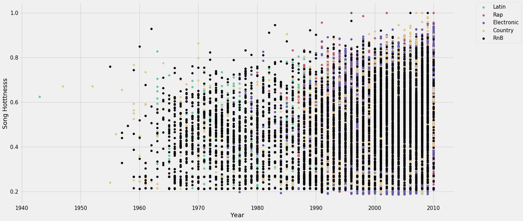

```python
# Latin
plt.scatter(data_with_genre_2['year'][data_with_genre_2['genre_id'] == 'Latin'],
            data_with_genre_2['song_hotttnesss'][data_with_genre_2['genre_id'] == 'Latin'],
            # the color
            color='#6ec59f',
            # alpha
            # labelled this
            label='Latin')

# Rap
plt.scatter(data_with_genre_2['year'][data_with_genre_2['genre_id'] == 'Rap'],
            data_with_genre_2['song_hotttnesss'][data_with_genre_2['genre_id'] == 'Rap'],
            # the color
            color='#bd6075',
            # labelled this
            label='Rap')

# Electronic
plt.scatter(data_with_genre_2['year'][data_with_genre_2['genre_id'] == 'Electronic'],
            data_with_genre_2['song_hotttnesss'][data_with_genre_2['genre_id'] == 'Electronic'],
            # the color
            color='#675aa3',
            # labelled this
            label='Electronic')

# Country
plt.scatter(data_with_genre_2['year'][data_with_genre_2['genre_id'] == 'Country'],
            data_with_genre_2['song_hotttnesss'][data_with_genre_2['genre_id'] == 'Country'],
            # the color
            color='#e2c890',
            # labelled this
            label='Country')

# RnB
plt.scatter(data_with_genre_2['year'][data_with_genre_2['genre_id'] == 'RnB'],
            data_with_genre_2['song_hotttnesss'][data_with_genre_2['genre_id'] == 'RnB'],
            # the color
            color='#020202',
            # labelled this
            label='RnB')

plt.legend(bbox_to_anchor=(1.05, 1), loc=2, borderaxespad=0.)
plt.xlabel('Year')
plt.ylabel('Song Hotttnesss')
```

### A Focus on Rap: 2Pac vs Biggie

On this part, we will be focusing on two rappers, 2Pac and Biggie, and show comparisons in the `artist_familiarity` and `arist_hotttnesss`.

```python
# Create a dataframe with rap as the genre_id
df_rap = data_with_genre[(data_with_genre.year != 0) & (data_with_genre.genre_id == 'Rap')]
# Create as dataframe of all rows rap as the genre_id except 2Pac and Biggie
df_rap_nob2 = df_rap[(df_rap.artist_name != '2Pac') | (df_rap.artist_name != 'The Notorious B.I.G.')]
```

```python
# Count number of tracks made by biggie
num_biggie = data_with_genre[data_with_genre.artist_name == 'The Notorious B.I.G.'].track_id.nunique()
print("Number of tracks by Biggie: {}".format(num_biggie))

# Count number of tracks made by 2Pac
num_2pac = data_with_genre[data_with_genre.artist_name == '2Pac'].track_id.nunique()
print("Number of tracks by 2Pac: {}".format(num_2pac))
```

```
Number of tracks by Biggie: 39
Number of tracks by 2Pac: 18
```

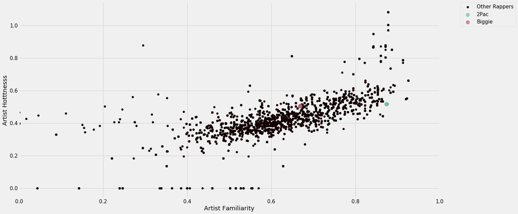

```python
# Rappers except biggie and 2pac
plt.scatter(df_rap_nob2['artist_familiarity'],
            df_rap_nob2['artist_hotttnesss'],
            # the color
            color='#150101',
            # labelled this
            label='Other Rappers')

# 2Pac
plt.scatter(df_rap['artist_familiarity'][df_rap['artist_name'] == '2Pac'],
            df_rap['artist_hotttnesss'][df_rap['artist_name'] == '2Pac'],
            # the color
            color='#6ec59f',
            # alpha
            alpha=0.7,
            # with size
            s = 124,
            # labelled this
            label='2Pac')

# Biggie
plt.scatter(df_rap['artist_familiarity'][df_rap['artist_name'] == 'The Notorious B.I.G.'],
            df_rap['artist_hotttnesss'][df_rap['artist_name'] == 'The Notorious B.I.G.'],
            # the color
            color='#bd6075',
            # alpha
            alpha=0.7,
            # with size
            s = 124,
            # labelled this
            label='Biggie')

plt.legend(bbox_to_anchor=(1.05, 1), loc=2, borderaxespad=0.)
plt.xlim((0,1))
plt.xlabel('Artist Familiarity')
plt.ylabel('Artist Hotttnesss')
```

```python
# Show artist_familiarity of Biggie
print(df_rap['artist_familiarity'][df_rap['artist_name'] == 'The Notorious B.I.G.'].head(n=1))
print(df_rap['artist_hotttnesss'][df_rap['artist_name'] == 'The Notorious B.I.G.'].head(n=1))
```

```
7308    0.668509
Name: artist_familiarity, dtype: float64
7308    0.506545
Name: artist_hotttnesss, dtype: float64
```

```python
# Show artist familiarity of 2Pac
print(df_rap['artist_familiarity'][df_rap['artist_name'] == '2Pac'].head(n=1))
print(df_rap['artist_hotttnesss'][df_rap['artist_name'] == '2Pac'].head(n=1))
```

```
50292    0.873187
Name: artist_familiarity, dtype: float64
50292    0.517256
Name: artist_hotttnesss, dtype: float64
```

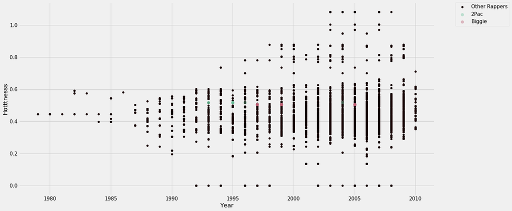

```python
# Rappers over the years except Biggie and 2Pac
plt.scatter(df_rap_nob2.year,
            df_rap_nob2.artist_hotttnesss,
            # the color
            color='#150101',
            # labelled this
            label='Other Rappers')

# 2Pac
plt.scatter(df_rap['year'][df_rap['artist_name'] == '2Pac'],
            df_rap['artist_hotttnesss'][df_rap['artist_name'] == '2Pac'],
            # the color
            color='#6ec59f',
            # alpha
            alpha=0.4,
            # with size
            s = 75,
            # labelled this
            label='2Pac')

# Biggie
plt.scatter(df_rap['year'][df_rap['artist_name'] == 'The Notorious B.I.G.'],
            df_rap['artist_hotttnesss'][df_rap['artist_name'] == 'The Notorious B.I.G.'],
            # the color
            color='#bd6075',
            # alpha
            alpha=0.4,
            # with size
            s = 75,
            # labelled this
            label='Biggie')

plt.legend(bbox_to_anchor=(1.05, 1), loc=2, borderaxespad=0.)
plt.xlabel('Year')
plt.ylabel('Hotttnesss')
```

On the visualization, we have seen that there is an artist with a `artist_hotttness` more than one (1). We need to know who is this and if this is bad data or not.

```python
# Show the artist with artist_hotttnesss of more than one (1)
df_rap[df_rap.artist_hotttnesss > 1][['artist_name', 'artist_hotttnesss']].head(n=1)
```

|  | artist_name | artist_hotttnesss |
| --- | --- | --- |
| 8579 | Kanye West | 1.082503 |